# Projekt1

Jerzy Jankowski

29 listopada 2015

## Spis treści

1. Podsumowanie
2. Kod wyliczający wykorzystane biblioteki;
3. Kod zapewniający powtarzalność wyników przy każdym uruchomieniu raportu na tych samych danych;
4. Kod pozwalający wczytać dane z pliku;
5. Kod usuwający z danych wiersze posiadające wartość zmiennej res_name równą: “DA”,“DC”,“DT”, “DU”, “DG”, “DI”,“UNK”, “UNX”, “UNL”, “PR”, “PD”, “Y1”, “EU”, “N”, “15P”, “UQ”, “PX4” lub “NAN”;
6. Kod pozostawiający tylko unikatowe pary wartości (pdb_code, res_name)
7. Krótkie podsumowanie wartości w każdej kolumnie;
8. Sekcje sprawdzającą korelacje między zmiennymi; sekcja ta powinna zawierać jakąś formę graficznej prezentacji korelacji;
   - Podejście 1 - atrybuty nie rozpoczynające się na “part_”
   - Podejście 2 - atrybuty rozpoczynające się na “part_00_”
   - Podejście 3 - porównanie atrybutów z dwóch poprzednich podejść
   - Podejście 4 - porównanie atrybutów rozpoczynających się na “part_00_” i “part_01_”
9. Określenie ile przykładów ma każda z klas (res_name);
10. Wykresy rozkładów liczby atomów (local_res_atom_non_h_count) i elektronów (local_res_atom_non_h_electron_sum);
11. Próbę odtworzenia następującego wykresu (oś X - liczba elektronów, oś y - liczba atomów): Wykres liczby atomów i elektronów
12. Tabelę pokazującą 10 klas z największą niezgodnością liczby atomów (local_res_atom_non_h_count vs dict_atom_non_h_count) i tabelę pokazującą 10 klas z największą niezgodnością liczby elektronów (local_res_atom_non_h_electron_sum vs dict_atom_non_h_electron_sum;)
13. Sekcję pokazującą rozkład wartości wszystkich kolumn zaczynających się od part_01 z zaznaczeniem (graficznym i liczbowym) średniej wartości;
14. Sekcję sprawdzającą czy na podstawie wartości innych kolumn można przewidzieć liczbę elektronów i atomów oraz z jaką dokładnością można dokonać takiej predykcji; trafność regresji powinna zostać oszacowana na podstawie miar R^2 i RMSE;
15. Sekcję próbującą stworzyć klasyfikator przewidujący wartość atrybutu res_name (w tej sekcji należy wykorzystać wiedzę z pozostałych punktów oraz wykonać dodatkowe czynności, które mogą poprawić trafność klasyfikacji); trafność klasyfikacji powinna zostać oszacowana na danych inne niż uczące za pomocą mechanizmu (stratyfikowanej!) oceny krzyżowej lub (stratyfikowanego!) zbioru testowego.

## Podsumowanie

#### Na podstawie opisu danych

Można wywnioskować, że kolumny zaczynające się od “part_” opisujące ten sam atrybut, ale z zamaskowanymi innymi intensywnościami (wg innego progu odcięcia) są ze sobą silnie skorelowane, dlatego też w poniższej analizie pominięto kolumny rozpoczynające się na part_0X, gdzie X to cyfra z zakresu 1-9. Zostało to także pokazane w zadaniu 7. Na podstawie zadania 6: Można wywnioskowa, że local_BAa, local_NPa, local_Ra, local_SRGa, local_CCSa, local_CCPa, local_ZOa, local_ZDa, local_ZD_minus_a, local_ZD_plus_a, weight_col zawierają jedynie wartości NA, natomiast kolumny: part_00_shape_I6_scaled, part_01_shape_I6_scaled, part_02_shape_I6_scaled, …, local_min, fo_col, fc_col, grid_space, solvent_radius, solvent_opening_radius, resolution_max_limit, part_step_FoFc_std_min, part_step_FoFc_std_max, part_step_FoFc_std_step zawierają taką samą wartość dla każdego wiersza. Powyższe kolumny zatem nie wnoszą żadnej znaczącej wiedzy.

#### Na podstawie zadania 7:

Grupy silnie skorelowanych ze sobą atrybutów:

- local_res_atom_count  
  local_res_atom_non_h_count  
  local_res_atom_non_h_occupancy_sum  
  local_res_atom_non_h_electron_sum  
  local_res_atom_non_h_electron_occupancy_sum  
  local_res_atom_C_count  
  local_res_atom_N_count  
  local_res_atom_O_count  
  local_res_atom_S_count  
  dict_atom_non_h_count  
  dict_atom_non_h_electron_sum  
  dict_atom_C_count  
  dict_atom_N_count  
  dict_atom_O_count  
  dict_atom_S_count  
  local_volume  
  local_electrons
- local_parts
- TwoFoFc_mean  
  Fo_mean  
  FoFc_mean
- Fc_mean
- solvent_mask_count  
  void_mask_count  
  modeled_mask_count  
  solvent_ratio
- TwoFoFc_bulk_std  
  Fo_bulk_mean  
  Fc_bulk_mean  
  TwoFoFc_solvent_fit_normal_mean
- TwoFoFc_modeled_mean  
  Fo_modeled_mean  
  Fc_modeled_mean
- FoFc_bulk_mean
- TwoFoFc_void_fit_binormal_scale
- TwoFoFc_void_fit_binormal_mean2  
  TwoFoFc_void_fit_binormal_std2
- local_mean  
  local_std  
  local_max  
  local_skewness  
  resolution  
  TwoFoFc_std  
  TwoFoFc_square_std  
  TwoFoFc_min  
  TwoFoFc_max  
  Fo_std  
  Fo_square_std  
  Fo_min  
  Fo_max  
  FoFc_std  
  FoFc_square_std  
  FoFc_min  
  FoFc_max  
  Fc_std  
  Fc_square_std  
  Fc_min  
  Fc_max  
  TwoFoFc_bulk_mean  
  TwoFoFc_void_mean  
  TwoFoFc_void_std  
  TwoFoFc_modeled_std  
  Fo_bulk_std  
  Fo_void_mean  
  Fo_void_std  
  Fo_modeled_std  
  FoFc_bulk_std  
  FoFc_void_mean  
  FoFc_void_std  
  FoFc_modeled_mean  
  FoFc_modeled_std  
  Fc_bulk_std  
  Fc_void_mean  
  Fc_void_std  
  Fc_modeled_std  
  TwoFoFc_void_fit_binormal_mean1  
  TwoFoFc_void_fit_binormal_std1  
  TwoFoFc_solvent_fit_normal_std

Można zauważyć, że część wykresu odpowiadająca za korelację atrybutów 4-36 jest bardzo podobna do korelacji atrybutów 37-69. Okazuje się, że atrybuty należące do pierwszej grupy noszą nazwy rozpoczynające się “part_00_shape_”, podczas gdy nazwy atrybutów z drugiej grupy zopoczynają się na “part_00_density_”, pozostałe części nazw dla odpowiednich kolumn są takie same. Grupy silnie skorelowanych ze sobą atrybutów:

- part_00_blob_electron_sum  
  part_00_blob_volume_sum  
  part_00_shape_O3  
  part_00_shape_M000  
  part_00_shape_sqrt_E1  
  part_00_shape_sqrt_E2  
  part_00_shape_sqrt_E3  
  part_00_density_O3  
  part_00_density_M000  
  part_00_density_sqrt_E1  
  part_00_density_sqrt_E2  
  part_00_density_sqrt_E3
- part_00_shape_O4  
  part_00_shape_O5  
  part_00_shape_FL  
  part_00_shape_I1  
  part_00_shape_I2  
  part_00_shape_I3  
  part_00_shape_I4  
  part_00_shape_I5  
  part_00_shape_I6  
  part_00_density_O4  
  part_00_density_O5  
  part_00_density_FL  
  part_00_density_I1  
  part_00_density_I2  
  part_00_density_I3  
  part_00_density_I4  
  part_00_density_I5  
  part_00_density_I6
- part_00_shape_O3_norm  
  part_00_shape_O4_norm  
  part_00_shape_O5_norm  
  part_00_shape_FL_norm  
  part_00_shape_I1_norm  
  part_00_shape_I2_norm  
  part_00_shape_I3_norm  
  part_00_shape_I4_norm  
  part_00_shape_I5_norm  
  part_00_shape_I6_norm  
  part_00_shape_I1_scaled  
  part_00_shape_I2_scaled  
  part_00_shape_I3_scaled  
  part_00_shape_I4_scaled  
  part_00_shape_I5_scaled  
  part_00_shape_I6_scaled
- part_00_shape_E3_E1  
  part_00_shape_E2_E1  
  part_00_shape_E3_E2  
  part_00_density_E3_E1  
  part_00_density_E2_E1  
  part_00_density_E3_E2
- part_00_density_I1_norm  
  part_00_density_I2_norm  
  part_00_density_I3_norm  
  part_00_density_I4_norm  
  part_00_density_I5_norm  
  part_00_density_I6_norm  
  part_00_density_I1_scaled
- part_00_density_I1_scaled(powtórzony zapis)  
  part_00_density_I2_scaled  
  part_00_density_I3_scaled  
  part_00_density_I4_scaled  
  part_00_density_I5_scaled  
  part_00_density_I6_scaled
- part_00_density_O3_norm  
  part_00_density_O4_norm  
  part_00_density_O5_norm  
  part_00_density_FL_norm
- part_00_blob_parts

Grupy atrybutów rozpoczynające się na “part_00_” i nie rozpoczynające się na “part_” są ze sobą bardzo słabo skorelowane. Natomiast dla grup atrybutów, których nazwy rozpoczynają się na “part_00_”, “part_01_”, itd. widać wyraźną analogię pomiędzy wartościami korelacji odpowiednich atrybutów Wykresy wyglądają jakby składały się z identycznych części.

#### Na podstawie zadania 13:

Jesteśmy w stanie z bardzo dużą dokładnością przewidzieć wartości local_res_atom_non_h_count ilocal_res_atom_non_h_electron_sum na podstawie innych kolumn. Wynika to z dużej korelacji danych.

#### Na podstawie zadania 14:

Udało się stworzyć klasyfikator przewidujący klasy z dużą dokładnością (0.9655). Idź do góry

## Zad1

Kod wyliczający wykorzystane biblioteki;

```r
library(knitr)
library(ggplot2)
library(corrplot)
library(reshape2)
library(MASS)
library(hexbin)
library(RColorBrewer)
library(dplyr)
library(corrplot)
library(caret)
library(pROC)
```

Idź do góry

## Zad2

Kod zapewniający powtarzalność wyników przy każdym uruchomieniu raportu na tych samych danych;

```r
set.seed(47)
```

## Zad3

Kod pozwalający wczytać dane z pliku;

```r
PDBdata3 <- read.table(file="all_summary.txt", header=TRUE, sep=";")
```

Idź do góry

## Zad4

Kod usuwający z danych wiersze posiadające wartość zmiennej res_name równą: “DA”,“DC”,“DT”, “DU”, “DG”, “DI”,“UNK”, “UNX”, “UNL”, “PR”, “PD”, “Y1”, “EU”, “N”, “15P”, “UQ”, “PX4” lub “NAN”

```r
forbiddenResNames <- c("DA","DC","DT", "DU", "DG", "DI","UNK", "UNX", "UNL", "PR", "PD", "Y1", "EU", "N", "15P", "UQ", "PX4", "NAN")
PDBdata4 <- dplyr::filter(PDBdata3, is.na(match(res_name, forbiddenResNames)))
```

Idź do góry

## Zad5

Kod pozostawiający tylko unikatowe pary wartości (pdb_code, res_name)

```r
PDBdata5 <- distinct(PDBdata4, diff = (paste(res_name,pdb_code)))
PDBdata5 <- select(PDBdata5, -diff)
```

Idź do góry

## Zad6

Krótkie podsumowanie wartości w każdej kolumnie;

```r
kable(summary(PDBdata5))
```

|  | title | pdb_code | res_name | res_id | chain_id | local_BAa | local_NPa | local_Ra | local_RGa | local_SRGa | local_CCSa | local_CCPa | local_ZOa | local_ZDa | local_ZD_minus_a | local_ZD_plus_a | local_res_atom_count | local_res_atom_non_h_count | local_res_atom_non_h_occupancy_sum | local_res_atom_non_h_electron_sum | local_res_atom_non_h_electron_occupancy_sum | local_res_atom_C_count | local_res_atom_N_count | local_res_atom_O_count | local_res_atom_S_count | dict_atom_non_h_count | dict_atom_non_h_electron_sum | dict_atom_C_count | dict_atom_N_count | … |
| --- | --- | --- | --- | --- | --- | --- | --- | --- | --- | --- | --- | --- | --- | --- | --- | --- | --- | --- | --- | --- | --- | --- | --- | --- | --- | --- | --- | --- | --- | --- |
|  | 110l BME 901 A: 1 | 3ag4 : 16 | SO4 : 1183 | 301 : 430 | A :8630 | Min. : NA | Min. : NA | Min. : NA | Min. : NA | Min. : NA | Min. : NA | Min. : NA | Min. : NA | Min. : NA | Min. : NA | Min. : NA | Min. : 1.00 | Min. : 1.00 | Min. : 0.00 | Min. : 3.0 | Min. : 0.00 | Min. : 0.000 | Min. : 0.00 | Min. : 0.000 | Min. :0.0000 | Min. : 1.00 | Min. : 3.0 | Min. : 0.00 | Min. : 0.000 | … |
|  | 111l CL 173 A : 1 | 3abl : 15 | ZN : 849 | 1 : 424 | B :2905 | 1st Qu.: NA | 1st Qu.: NA | 1st Qu.: NA | 1st Qu.: NA | 1st Qu.: NA | 1st Qu.: NA | 1st Qu.: NA | 1st Qu.: NA | 1st Qu.: NA | 1st Qu.: NA | 1st Qu.: NA | 1st Qu.: 1.00 | 1st Qu.: 1.00 | 1st Qu.: 1.00 | 1st Qu.: 30.0 | 1st Qu.: 30.00 | 1st Qu.: 0.000 | 1st Qu.: 0.00 | 1st Qu.: 0.000 | 1st Qu.:0.0000 | 1st Qu.: 1.00 | 1st Qu.: 30.0 | 1st Qu.: 0.00 | 1st Qu.: 0.000 | … |
|  | 115l BME 901 A: 1 | 3abk : 14 | GOL : 778 | 501 : 417 | C : 795 | Median : NA | Median : NA | Median : NA | Median : NA | Median : NA | Median : NA | Median : NA | Median : NA | Median : NA | Median : NA | Median : NA | Median : 7.00 | Median : 7.00 | Median : 7.00 | Median : 55.0 | Median : 52.00 | Median : 3.000 | Median : 0.00 | Median : 3.000 | Median :0.0000 | Median : 7.00 | Median : 56.0 | Median : 3.00 | Median : 0.000 | … |
|  | 115l CL 173 A : 1 | 2afh : 11 | CA : 661 | 401 : 395 | D : 552 | Mean :NaN | Mean :NaN | Mean :NaN | Mean :NaN | Mean :NaN | Mean :NaN | Mean :NaN | Mean :NaN | Mean :NaN | Mean :NaN | Mean :NaN | Mean : 13.59 | Mean : 13.43 | Mean : 13.05 | Mean :101.5 | Mean : 98.33 | Mean : 7.332 | Mean : 1.35 | Mean : 3.817 | Mean :0.2208 | Mean : 13.74 | Mean :103.8 | Mean : 7.47 | Mean : 1.357 | … |
|  | 123l BME 901 A: 1 | 3a0b : 11 | MG : 402 | 201 : 306 | E : 221 | 3rd Qu.: NA | 3rd Qu.: NA | 3rd Qu.: NA | 3rd Qu.: NA | 3rd Qu.: NA | 3rd Qu.: NA | 3rd Qu.: NA | 3rd Qu.: NA | 3rd Qu.: NA | 3rd Qu.: NA | 3rd Qu.: NA | 3rd Qu.: 21.00 | 3rd Qu.: 20.00 | 3rd Qu.: 20.00 | 3rd Qu.:145.0 | 3rd Qu.:139.15 | 3rd Qu.:10.000 | 3rd Qu.: 2.00 | 3rd Qu.: 5.000 | 3rd Qu.:0.0000 | 3rd Qu.: 21.00 | 3rd Qu.:151.0 | 3rd Qu.:10.00 | 3rd Qu.: 2.000 | … |
|  | 123l CL 173 A : 1 | 3g6e : 11 | (Other):10021 | 500 : 228 | H : 153 | Max. : NA | Max. : NA | Max. : NA | Max. : NA | Max. : NA | Max. : NA | Max. : NA | Max. : NA | Max. : NA | Max. : NA | Max. : NA | Max. :178.00 | Max. :104.00 | Max. :104.00 | Max. :800.0 | Max. :800.00 | Max. :81.000 | Max. :15.00 | Max. :55.000 | Max. :9.0000 | Max. :128.00 | Max. :866.0 | Max. :81.00 | Max. :20.000 | … |
|  | (Other) :14126 | (Other):14054 | NA’s : 238 | (Other):11932 | (Other): 876 | NA’s :14132 | NA’s :14132 | NA’s :14132 | NA’s :14132 | NA’s :14132 | NA’s :14132 | NA’s :14132 | NA’s :14132 | NA’s :14132 | NA’s :14132 | NA’s :14132 | NA | NA | NA | NA | NA | NA | NA | NA | NA | NA’s :19 | NA’s :19 | NA’s :19 | NA’s :19 | … |

#### Wnioski

Można wywnioskowa, że local_BAa, local_NPa, local_Ra, local_SRGa, local_CCSa, local_CCPa, local_ZOa, local_ZDa, local_ZD_minus_a, local_ZD_plus_a, weight_col zawierają jedynie wartości NA, natomiast kolumny: part_00_shape_I6_scaled, part_01_shape_I6_scaled, part_02_shape_I6_scaled, …, local_min, fo_col, fc_col, grid_space, solvent_radius, solvent_opening_radius, resolution_max_limit, part_step_FoFc_std_min, part_step_FoFc_std_max, part_step_FoFc_std_step zawierają taką samą wartość dla każdego wiersza. Powyższe kolumny zatem nie wnoszą żadnej znaczącej wiedzy.

Idź do góry

## Zad7

Sekcje sprawdzającą korelacje między zmiennymi; sekcja ta powinna zawierać jakąś formę graficznej prezentacji korelacji;

### Podejście 1

Wyodrębnione zostały atrybuty, których nazwy nie zaczynają się na “part_”.

```r
PDBdata7 <- PDBdata5[sapply(PDBdata5, is.numeric)]
PDBdata7 <- PDBdata7[12:ncol(PDBdata7)]
PDBdata7 <- select(PDBdata7, -local_min, -grid_space, -solvent_radius, -solvent_opening_radius, -resolution_max_limit)
PDBdata7 <- select(PDBdata7, -starts_with("part_"))
PDBdata7 <- PDBdata7[complete.cases(PDBdata7),]

legend <- colnames(PDBdata7)
colnames(PDBdata7) <- 1: ncol(PDBdata7)
```

#### Wykres

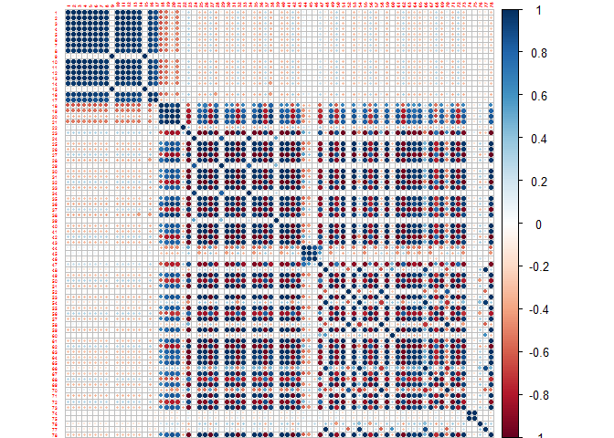

```r
#Wykorzystana poniżej funkcja 'calculateBigCorr' to funkcja autorska, która dzieli zadany data frame na mniejsze bloki, wylicza dla nich macierz korelacji. Wynikowa macierz korelacji jest macierzą sklejoną z pozostałych.
corrplot(cor(calculateBigCorr(PDBdata7, 20), method="pearson"), method = "circle", type="full", tl.cex=0.3, sub="title")
```

#### Legenda

```r
cat(paste(1:ncol(PDBdata7), legend, sep=" - ", collapse="\n"))
```

```
## 1 - local_res_atom_count
## 2 - local_res_atom_non_h_count
## 3 - local_res_atom_non_h_occupancy_sum
## 4 - local_res_atom_non_h_electron_sum
## 5 - local_res_atom_non_h_electron_occupancy_sum
## 6 - local_res_atom_C_count
## 7 - local_res_atom_N_count
## 8 - local_res_atom_O_count
## 9 - local_res_atom_S_count
## 10 - dict_atom_non_h_count
## 11 - dict_atom_non_h_electron_sum
## 12 - dict_atom_C_count
## 13 - dict_atom_N_count
## 14 - dict_atom_O_count
## 15 - dict_atom_S_count
```

[output cut: 63 more lines]

#### Wnioski

Grupy silnie skorelowanych ze sobą atrybutów:

- local_res_atom_count  
  local_res_atom_non_h_count  
  local_res_atom_non_h_occupancy_sum  
  local_res_atom_non_h_electron_sum  
  local_res_atom_non_h_electron_occupancy_sum  
  local_res_atom_C_count  
  local_res_atom_N_count  
  local_res_atom_O_count  
  local_res_atom_S_count  
  dict_atom_non_h_count  
  dict_atom_non_h_electron_sum  
  dict_atom_C_count  
  dict_atom_N_count  
  dict_atom_O_count  
  dict_atom_S_count  
  local_volume  
  local_electrons
- local_parts
- TwoFoFc_mean  
  Fo_mean  
  FoFc_mean
- Fc_mean
- solvent_mask_count  
  void_mask_count  
  modeled_mask_count  
  solvent_ratio
- TwoFoFc_bulk_std  
  Fo_bulk_mean  
  Fc_bulk_mean  
  TwoFoFc_solvent_fit_normal_mean
- TwoFoFc_modeled_mean  
  Fo_modeled_mean  
  Fc_modeled_mean
- FoFc_bulk_mean
- TwoFoFc_void_fit_binormal_scale
- TwoFoFc_void_fit_binormal_mean2  
  TwoFoFc_void_fit_binormal_std2
- local_mean  
  local_std  
  local_max  
  local_skewness  
  resolution  
  TwoFoFc_std  
  TwoFoFc_square_std  
  TwoFoFc_min  
  TwoFoFc_max  
  Fo_std  
  Fo_square_std  
  Fo_min  
  Fo_max  
  FoFc_std  
  FoFc_square_std  
  FoFc_min  
  FoFc_max  
  Fc_std  
  Fc_square_std  
  Fc_min  
  Fc_max  
  TwoFoFc_bulk_mean  
  TwoFoFc_void_mean  
  TwoFoFc_void_std  
  TwoFoFc_modeled_std  
  Fo_bulk_std  
  Fo_void_mean  
  Fo_void_std  
  Fo_modeled_std  
  FoFc_bulk_std  
  FoFc_void_mean  
  FoFc_void_std  
  FoFc_modeled_mean  
  FoFc_modeled_std  
  Fc_bulk_std  
  Fc_void_mean  
  Fc_void_std  
  Fc_modeled_std  
  TwoFoFc_void_fit_binormal_mean1  
  TwoFoFc_void_fit_binormal_std1  
  TwoFoFc_solvent_fit_normal_std

Idź do góry

### Podejście 2

Atrybuty zaczynające się na “part00_”

```r
PDBdata7_2 <- PDBdata5[sapply(PDBdata5, is.numeric)]
PDBdata7_2 <- PDBdata7_2[12:ncol(PDBdata7_2)]
PDBdata7_2 <- select(PDBdata7_2, matches("^part_00_.*$"))
#PDBdata7_2 <- select(PDBdata7_2, -local_min, -grid_space, -solvent_radius, -solvent_opening_radius, -resolution_max_limit, -part_step_FoFc_std_min,    -part_step_FoFc_std_max, -part_step_FoFc_std_step)
PDBdata7_2 <- PDBdata7_2[complete.cases(PDBdata7_2),]
legend <- colnames(PDBdata7_2)
colnames(PDBdata7_2) <- 1: ncol(PDBdata7_2)
```

#### Wykres

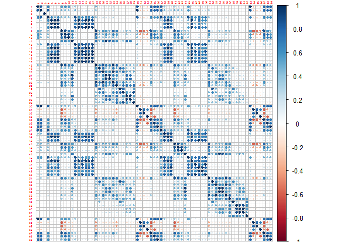

```r
corrplot((calculateBigCorr(PDBdata7_2, 20)), method = "circle", type="full", tl.cex=0.3)
```

#### Legenda

```r
cat(paste(1:ncol(PDBdata7_2), legend, sep=" - ", collapse="\n"))
```

```
## 1 - part_00_blob_electron_sum
## 2 - part_00_blob_volume_sum
## 3 - part_00_blob_parts
## 4 - part_00_shape_O3
## 5 - part_00_shape_O4
## 6 - part_00_shape_O5
## 7 - part_00_shape_FL
## 8 - part_00_shape_O3_norm
## 9 - part_00_shape_O4_norm
## 10 - part_00_shape_O5_norm
## 11 - part_00_shape_FL_norm
## 12 - part_00_shape_I1
## 13 - part_00_shape_I2
## 14 - part_00_shape_I3
## 15 - part_00_shape_I4
```

[output cut: 54 more lines]

#### Wnioski

Można zauważyć, że część wykresu odpowiadająca za korelację atrybutów 4-36 jest bardzo podobna do korelacji atrybutów 37-69. Okazuje się, że atrybuty należące do pierwszej grupy noszą nazwy rozpoczynające się “part_00_shape_”, podczas gdy nazwy atrybutów z drugiej grupy zopoczynają się na “part_00_density_”, pozostałe części nazw dla odpowiednich kolumn są takie same. Grupy silnie skorelowanych ze sobą atrybutów:

- part_00_blob_electron_sum  
  part_00_blob_volume_sum  
  part_00_shape_O3  
  part_00_shape_M000  
  part_00_shape_sqrt_E1  
  part_00_shape_sqrt_E2  
  part_00_shape_sqrt_E3  
  part_00_density_O3  
  part_00_density_M000  
  part_00_density_sqrt_E1  
  part_00_density_sqrt_E2  
  part_00_density_sqrt_E3
- part_00_shape_O4  
  part_00_shape_O5  
  part_00_shape_FL  
  part_00_shape_I1  
  part_00_shape_I2  
  part_00_shape_I3  
  part_00_shape_I4  
  part_00_shape_I5  
  part_00_shape_I6  
  part_00_density_O4  
  part_00_density_O5  
  part_00_density_FL  
  part_00_density_I1  
  part_00_density_I2  
  part_00_density_I3  
  part_00_density_I4  
  part_00_density_I5  
  part_00_density_I6
- part_00_shape_O3_norm  
  part_00_shape_O4_norm  
  part_00_shape_O5_norm  
  part_00_shape_FL_norm  
  part_00_shape_I1_norm  
  part_00_shape_I2_norm  
  part_00_shape_I3_norm  
  part_00_shape_I4_norm  
  part_00_shape_I5_norm  
  part_00_shape_I6_norm  
  part_00_shape_I1_scaled  
  part_00_shape_I2_scaled  
  part_00_shape_I3_scaled  
  part_00_shape_I4_scaled  
  part_00_shape_I5_scaled  
  part_00_shape_I6_scaled
- part_00_shape_E3_E1  
  part_00_shape_E2_E1  
  part_00_shape_E3_E2  
  part_00_density_E3_E1  
  part_00_density_E2_E1  
  part_00_density_E3_E2
- part_00_density_I1_norm  
  part_00_density_I2_norm  
  part_00_density_I3_norm  
  part_00_density_I4_norm  
  part_00_density_I5_norm  
  part_00_density_I6_norm  
  part_00_density_I1_scaled
- part_00_density_I1_scaled(powtórzony zapis)  
  part_00_density_I2_scaled  
  part_00_density_I3_scaled  
  part_00_density_I4_scaled  
  part_00_density_I5_scaled  
  part_00_density_I6_scaled
- part_00_density_O3_norm  
  part_00_density_O4_norm  
  part_00_density_O5_norm  
  part_00_density_FL_norm
- part_00_blob_parts

Idź do góry

### Podejście 3

Porównanie ze sobą atrybutów z podejścia 1 (nie zaczynające się na “part_0”) z atrybutami z podejścia 2 (zaczynające się na “part_00”)

```r
PDBdata7_3 <- PDBdata5[sapply(PDBdata5, is.numeric)]
PDBdata7_3 <- PDBdata7_3[12:ncol(PDBdata7_3)]
PDBdata7_3 <- select(PDBdata7_3, -matches("^part_0[123456789]_.*$"))
PDBdata7_3 <- select(PDBdata7_3, -local_min, -grid_space, -solvent_radius, -solvent_opening_radius, -resolution_max_limit, -part_step_FoFc_std_min, -part_step_FoFc_std_max, -part_step_FoFc_std_step)
PDBdata7_3 <- PDBdata7_3[complete.cases(PDBdata7_3),]
legend <- colnames(PDBdata7_3)
colnames(PDBdata7_3) <- 1: ncol(PDBdata7_3)
```

#### Wykres

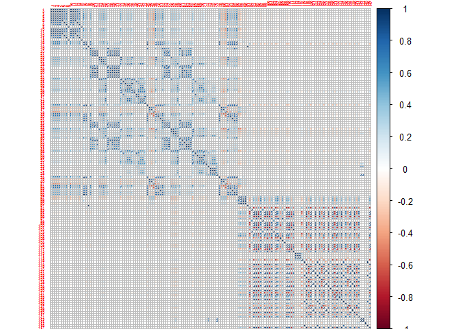

```r
corrplot((calculateBigCorr(PDBdata7_3, 20)), method = "circle", type="full", tl.cex=0.3)
```

#### Legenda

```r
cat(paste(1:ncol(PDBdata7_3), legend, sep=" - ", collapse="\n"))
```

```
## 1 - local_res_atom_count
## 2 - local_res_atom_non_h_count
## 3 - local_res_atom_non_h_occupancy_sum
## 4 - local_res_atom_non_h_electron_sum
## 5 - local_res_atom_non_h_electron_occupancy_sum
## 6 - local_res_atom_C_count
## 7 - local_res_atom_N_count
## 8 - local_res_atom_O_count
## 9 - local_res_atom_S_count
## 10 - dict_atom_non_h_count
## 11 - dict_atom_non_h_electron_sum
## 12 - dict_atom_C_count
## 13 - dict_atom_N_count
## 14 - dict_atom_O_count
## 15 - dict_atom_S_count
```

[output cut: 132 more lines]

#### Wnioski

Wybrane grupy atrybutów generalnie nie są ze sobą skorelowane. Idź do góry

### Podejście 4

Porównanie ze sobą atrybutów rozpoczynających się na “part_00_” i “part_01”

```r
PDBdata7_4 <- PDBdata5[sapply(PDBdata5, is.numeric)]
PDBdata7_4 <- PDBdata7_4[12:ncol(PDBdata7_4)]
PDBdata7_4 <- select(PDBdata7_4, matches("^part_0[01]_.*$"))
#PDBdata7_3 <- select(PDBdata7_2, -local_min, -grid_space, -solvent_radius, -solvent_opening_radius, -resolution_max_limit, -part_step_FoFc_std_min,    -part_step_FoFc_std_max, -part_step_FoFc_std_step)
PDBdata7_4 <- PDBdata7_4[complete.cases(PDBdata7_4),]
legend <- colnames(PDBdata7_4)
colnames(PDBdata7_4) <- 1: ncol(PDBdata7_4)
```

#### Wykres

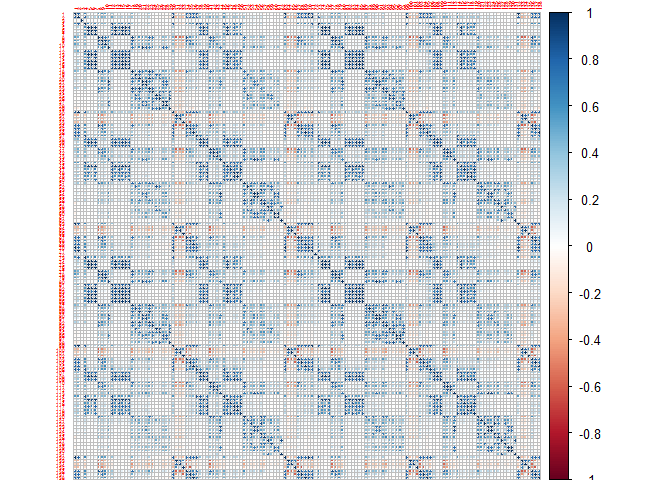

```r
corrplot((calculateBigCorr(PDBdata7_4, 20)), method = "circle", type="full", tl.cex=0.3)
```

#### Legenda

```r
cat(paste(1:ncol(PDBdata7_4), legend, sep=" - ", collapse="\n"))
```

```
## 1 - part_00_blob_electron_sum
## 2 - part_00_blob_volume_sum
## 3 - part_00_blob_parts
## 4 - part_00_shape_O3
## 5 - part_00_shape_O4
## 6 - part_00_shape_O5
## 7 - part_00_shape_FL
## 8 - part_00_shape_O3_norm
## 9 - part_00_shape_O4_norm
## 10 - part_00_shape_O5_norm
## 11 - part_00_shape_FL_norm
## 12 - part_00_shape_I1
## 13 - part_00_shape_I2
## 14 - part_00_shape_I3
## 15 - part_00_shape_I4
```

[output cut: 123 more lines]

#### Wnioski

Widać wyraźną analogię pomiędzy wartościami korelacji odpowiednich atrybutów. Wykres wygląda jakby składał się z czterech niemal identycznych części. Idź do góry

## Zad8

Określenie ile przykładów ma każda z klas (res_name);

```r
#table(PDBdata5$res_name)
data.frame(select(PDBdata5,res_name) %>% group_by(res_name) %>% summarize(count=n()) %>% arrange(desc(count)))
```

```
##      res_name count
## 1         SO4  1183
## 2          ZN   849
## 3         GOL   778
## 4          CA   661
## 5          MG   402
## 6          CL   400
## 7         NAG   396
## 8         PO4   301
## 9         HEM   296
## 10        EDO   274
## 11       <NA>   238
## 12         MN   182
## 13        ACT   167
## 14        FAD   157
```

[output cut: 2671 more lines]

Idź do góry

## Zad9

Wykresy rozkładów liczby atomów (local_res_atom_non_h_count) i elektronów (local_res_atom_non_h_electron_sum);

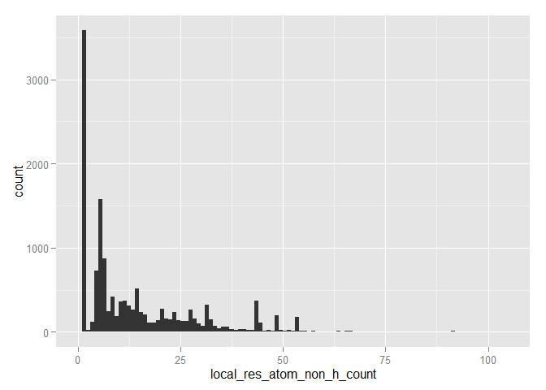

```r
df1 <- data.frame(select(PDBdata5, local_res_atom_non_h_count))%>% filter(!is.na(local_res_atom_non_h_count))
ggplot(df1, aes(local_res_atom_non_h_count)) + geom_bar(binwidth = 1)
```

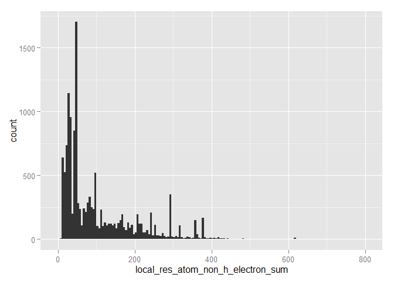

```r
df2 <- select(PDBdata5, local_res_atom_non_h_electron_sum) %>% filter(!is.na(local_res_atom_non_h_electron_sum))
ggplot(df2, aes(local_res_atom_non_h_electron_sum)) + geom_bar(binwidth = 5)
```

#### Wnioski

Na 2685 różnych nazw klas, 2015 z nich występuje raz, 260 - dwa razy, 115 - trzy razy, 62 - cztery razy, 39 - 6 razy, 92 - sześć do dziesięć razy, 49 - jedenaście do dwadzieścia razy. Tylko 53 klasy występują ponad dwadzieścia razy w danych wyizolowanych z punku 5 powyższej analizy.

Idź do góry

## Zad10

Próbę odtworzenia wykresu (oś X - liczba elektronów, oś y - liczba atomów):

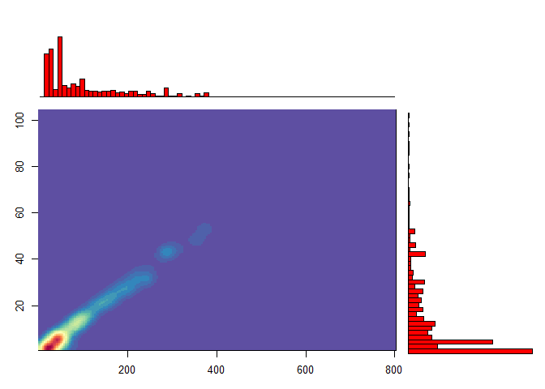

```r
rf <- colorRampPalette(rev(brewer.pal(11,'Spectral')))
r <- rf(32)

maxc <- max(PDBdata5$local_res_atom_non_h_count)
maxh <- max(PDBdata5$local_res_atom_non_h_electron_sum)

zad10x <- PDBdata5$local_res_atom_non_h_count
zad10y <- PDBdata5$local_res_atom_non_h_electron_sum

h1 <- hist(zad10y, breaks=100, plot=F)
h2 <- hist(zad10x, breaks=50, plot=F)
top <- max(h1$counts, h2$counts)
k <- kde2d(zad10y, zad10x, n=200)

oldpar <- par()
par(mar=c(3,3,1,1))
layout(matrix(c(2,0,1,3),2,2,byrow=T),c(3,1), c(1,3))
image(k, col=r)
par(mar=c(0,2,1,0))
barplot(h1$counts, axes=F, ylim=c(-10, top), space=0, col='red')
par(mar=c(2,0,0.5,1))
barplot(h2$counts, axes=F, xlim=c(0, top), space=0, col='red', horiz=T)
```

Idź do góry

## Zad11

Tabelę pokazującą 10 klas z największą niezgodnością liczby atomów (local_res_atom_non_h_count vs dict_atom_non_h_count) i tabelę pokazującą 10 klas z największą niezgodnością liczby elektronów (local_res_atom_non_h_electron_sum vs dict_atom_non_h_electron_sum;)

```r
head(
  mutate(PDBdata5, diff=abs(local_res_atom_non_h_count - dict_atom_non_h_count))
    %>%dplyr::select(res_name, diff)
    %>%group_by(res_name)
    %>%summarise(sumDiff = sum(diff))
    %>%arrange(desc(sumDiff))
  ,10)
```

```
## Source: local data frame [10 x 2]
##
##    res_name sumDiff
##      (fctr)   (dbl)
## 1       NAG     386
## 2       CDL     223
## 3       PEU     133
## 4       U10     126
## 5       LMT     106
## 6       PC1     100
## 7       12P      68
## 8       PLC      66
## 9       PEE      64
## 10      PTY      62
```

```r
head(
  mutate(PDBdata5, diff=abs(local_res_atom_non_h_electron_sum  - dict_atom_non_h_electron_sum))
    %>%dplyr::select(res_name, diff)
    %>%group_by(res_name)
    %>%summarise(sumDiff = sum(diff))
    %>%arrange(desc(sumDiff))
  ,10)
```

```
## Source: local data frame [10 x 2]
##
##    res_name sumDiff
##      (fctr)   (dbl)
## 1       NAG    3088
## 2       CDL    1340
## 3       PEU     886
## 4       U10     756
## 5       LMT     702
## 6       PC1     635
## 7       SEP     464
## 8       12P     460
## 9       MAN     440
## 10      PEE     436
```

Idź do góry

## Zad12

Sekcję pokazującą rozkład wartości wszystkich kolumn zaczynających się od part_01 z zaznaczeniem (graficznym i liczbowym) średniej wartości;

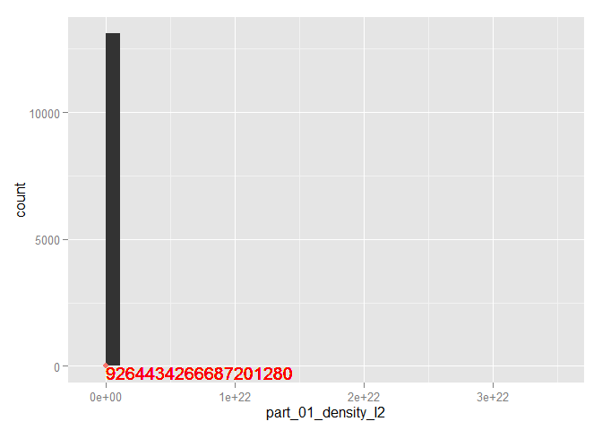

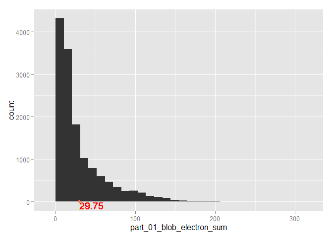

```r
#part01Cols <- dplyr::select(PDBdata5, starts_with("part_01"))
part01Cols <- dplyr::select(PDBdata5, part_01_density_I2, part_01_blob_electron_sum)

for(i in names(part01Cols)) {
  part01ColsN <- part01Cols[[i]][!is.na(part01Cols[[i]])]
  meanPart <- mean(part01ColsN)
  print(ggplot(part01Cols, aes(x=part01Cols[[i]], ifelse=!is.na(part01Cols[[i]]))) + geom_bar() + xlab(i)+ theme(legend.position="none")
         + geom_point(aes(x=meanPart,y=0, colour="red"))
         + geom_text(aes(label=round(meanPart,2), x=meanPart, y=0),hjust=0, vjust=1, colour="red")
  )
}
```

Idź do góry

## Zad13

Sekcję sprawdzającą czy na podstawie wartości innych kolumn można przewidzieć liczbę elektronów i atomów oraz z jaką dokładnością można dokonać takiej predykcji; trafność regresji powinna zostać oszacowana na podstawie miar R^2 i RMSE;

```r
PDBdata13 <- PDBdata5[sapply(PDBdata5, is.numeric)]
PDBdata13 <- PDBdata13[12:ncol(PDBdata13)]
PDBdata13 <- PDBdata13[complete.cases(PDBdata13),]

mod <- lm(PDBdata13$local_res_atom_non_h_count ~ . , data = PDBdata13)
r2 <- summary(mod)$r.squared
rmse <- summary(mod)$sigma
```

```
## [1] "Funkcja regresji dla local_res_atom_non_h_count:"
```

```
## [1] "R^2, 0.999999673251451=RMSE, 0.011969489252716"
```

```r
mod <- lm(PDBdata13$local_res_atom_non_h_electron_sum ~ . , data = PDBdata13)
r2 <- summary(mod)$r.squared
rmse <- summary(mod)$sigma
```

```
## [1] "Funkcja regresji dla local_res_atom_non_h_electron_sum:"
```

```
## [1] "R^2, 0.999998356638752=RMSE, 0.176910982252278"
```

#### Wnioski

Z bardzo dużą dokładnością można przewidzieć wartości local_res_atom_non_h_count ilocal_res_atom_non_h_electron_sum na podstawie innych kolumn.

Idź do góry

## Zad14

Sekcję próbującą stworzyć klasyfikator przewidujący wartość atrybutu res_name (w tej sekcji należy wykorzystać wiedzę z pozostałych punktów oraz wykonać dodatkowe czynności, które mogą poprawić trafność klasyfikacji); trafność klasyfikacji powinna zostać oszacowana na danych inne niż uczące za pomocą mechanizmu (stratyfikowanej!) oceny krzyżowej lub (stratyfikowanego!) zbioru testowego.

```r
PDBdata14 <- select(PDBdata5, -title, -matches("part_0[123456789]_"))

PDBdata14$res_name_factor<-factor(PDBdata14$res_name)
PDBdata14 <- select(PDBdata14, -res_name)

xtab <- as.data.frame(table(select(PDBdata14, res_name_factor)))
xtab <- filter(xtab, Freq>=50)

PDBdata14_2 <- dplyr::filter(PDBdata14, !is.na(match(res_name_factor, xtab$Var1)))
PDBdata14_3 <- select(PDBdata14_2, -weight_col,-(5:15), -local_BAa, -local_min, -fo_col, -fc_col, -grid_space,  -solvent_radius, -solvent_opening_radius, -resolution_max_limit, -pdb_code, -chain_id, -res_id)
PDBdata14_4 <- PDBdata14_3[complete.cases(PDBdata14_3),]

c <- (PDBdata14_4$res_name_factor)
c <- as.vector(c)
res_name_2 <- as.factor(c)
PDBdata14_5 <- cbind(PDBdata14_4, res_name_2)
PDBdata14_5 <- select(PDBdata14_5, -res_name_factor)
```

```r
inTraining <-
  createDataPartition(
    y = PDBdata14_5$res_name_2,
    p = .70,
    list = FALSE)

training <- PDBdata14_5[ inTraining,]
testing  <- PDBdata14_5[-inTraining,]


gridCtrl <- trainControl(
  method = "repeatedcv",
  classProbs = TRUE,
  number = 2,
  repeats = 2)

rfGrid <- expand.grid(mtry = 14)
```

```r
rfFit <- train(res_name_2~.,
               data=training,
               method="rf",
                metric = "ROC",
               trControl = gridCtrl,
               tuneGrid = rfGrid,
             ntree = 10)
```

```r
rfClasses <- predict(rfFit, newdata = testing)
confusionMatrix(data = rfClasses, testing$res_name)
```

```
## Confusion Matrix and Statistics
##
##           Reference
## Prediction ACT ADP ATP BME  CA  CD CIT  CL  CO  CU EDO EPE FAD  FE FE2 FMN
##        ACT  31   0   0   0   0   0   0   0   0   0  14   0   0   0   0   0
##        ADP   0  40   0   0   0   0   0   0   0   0   0   0   0   0   0   0
##        ATP   0   0  31   0   0   0   0   0   0   0   0   0   0   0   0   0
##        BME   0   0   0  18   0   0   0   0   0   0   0   0   0   0   0   0
##        CA    0   0   0   0 189   0   0   0   1   2   0   0   0   6   1   0
##        CD    0   0   0   0   0  23   0   0   0   0   0   0   0   0   0   0
##        CIT   0   0   0   0   0   0  15   0   0   0   0   0   0   0   0   0
##        CL    0   0   0   0   0   0   0 105   1   1   0   0   0   0   0   0
##        CO    0   0   0   0   0   0   0   0   7   0   0   0   0   0   1   0
##        CU    0   0   0   0   0   0   0   0   1  16   0   0   0   0   0   0
##        EDO  15   0   0   0   0   0   0   0   0   0  61   0   0   0   0   0
##        EPE   0   0   0   0   0   0   0   0   0   0   0  21   0   0   0   0
##        FAD   0   0   0   0   0   0   0   0   0   0   0   0  45   0   0   0
##        FE    0   0   0   0   0   0   0   0   3   1   0   0   0  19   9   0
##        FE2   0   0   0   0   0   0   0   0   0   3   0   0   0   3   3   0
##        FMN   0   0   0   0   0   0   0   0   0   0   0   0   0   0   0  20
##        GDP   0   0   0   0   0   0   0   0   0   0   0   0   0   0   0   0
##        GOL   0   0   0   0   0   0   0   0   0   0   0   0   0   0   0   0
##        HEM   0   0   0   0   0   0   0   0   0   0   0   0   0   0   0   0
##        K     0   0   0   0   0   0   0   1   0   0   0   0   0   0   0   0
##        MAN   0   0   0   0   0   0   0   0   0   0   0   0   0   0   0   0
##        MES   0   0   0   0   0   0   0   0   0   0   0   0   0   0   0   0
##        MG    0   0   0   0   0   0   0   2   0   0   0   0   0   0   0   0
##        MN    0   0   0   0   0   0   0   0   2   2   0   0   0   4   1   0
##        MPD   0   0   0   0   0   0   0   0   0   0   0   0   0   0   0   0
##        NAD   0   0   0   0   0   0   0   0   0   0   0   0   0   0   0   0
##        NAG   0   0   0   0   0   0   0   0   0   0   0   0   0   0   0   0
##        NAP   0   0   0   0   0   0   0   0   0   0   0   0   0   0   0   0
##        NDP   0   0   0   0   0   0   0   0   0   0   0   0   0   0   0   0
##        NI    0   0   0   0   0   0   0   0   2   3   0   0   0   1   0   0
##        PEG   0   0   0   0   0   0   0   0   0   0   0   0   0   0   0   0
##        PG4   0   0   0   0   0   0   0   0   0   0   0   0   0   0   0   0
##        PLP   0   0   0   0   0   0   0   0   0   0   0   0   0   0   0   1
##        PO4   0   0   0   0   0   0   0   0   0   0   0   0   0   0   0   0
##        SAH   0   0   0   0   0   0   0   0   0   0   0   0   0   0   0   0
##        SEP   0   0   0   0   0   0   0   0   0   0   0   0   0   0   0   0
```

[output cut: 167 more lines]

```
## Pos Pred Value         1.000000   1.000000     1.0000   1.000000
## Neg Pred Value         1.000000   1.000000     1.0000   1.000000
## Prevalence             0.006542   0.007414     0.1491   0.005669
## Detection Rate         0.006542   0.007414     0.1491   0.005669
## Detection Prevalence   0.006542   0.007414     0.1491   0.005669
## Balanced Accuracy      1.000000   1.000000     1.0000   1.000000
##                      Class: TRS Class: ZN
## Sensitivity             1.00000    1.0000
## Specificity             1.00000    0.9990
## Pos Pred Value          1.00000    0.9919
## Neg Pred Value          1.00000    1.0000
## Prevalence              0.00785    0.1068
## Detection Rate          0.00785    0.1068
## Detection Prevalence    0.00785    0.1077
## Balanced Accuracy       1.00000    0.9995
```

#### Wnioski

Stworzony klasyfikator przewiduje klasy z dużą dokładnością (0.9655).

Idź do góry